# Dr.Daneshgar Data Analysis

Veronica Marquez

get file location

```r
getwd()
```

```
[1] "/Users/veronicamarquez/Desktop/Dr.D Ecology Bias SC/MA321-Daneshgar"
```

run library

```r
library(mosaic)
```

```r
library(readxl)
EcologyBias_Daneshgar_Popo_2_ <- read_excel("/Users/veronicamarquez/Desktop/Dr.D Ecology Bias SC/MA321-Daneshgar/EcologyBias.Daneshgar.Popo.xlsx")
View(EcologyBias_Daneshgar_Popo_2_)
```

```r
EcologyBias <- EcologyBias_Daneshgar_Popo_2_[1:175, ]
```

Looking to see how many of each ecosystem exists in the data set

```r
cat("# of Journals in Marine: ", count(EcologyBias$`Marine, Terrestrial, Freshwater, Mixed` == "Marine"), "\n")
```

```
# of Journals in Marine:  20
```

```r
cat("# of Journals in Terrestrial: ", count(EcologyBias$`Marine, Terrestrial, Freshwater, Mixed` == "Terrestrial"), "\n")
```

```
# of Journals in Terrestrial:  127
```

```r
cat("# of Journals in Frshwater: ", count(EcologyBias$`Marine, Terrestrial, Freshwater, Mixed` == "Freshwater"), "\n")
```

```
# of Journals in Frshwater:  12
```

```r
cat("# of Journals in Mixed: ", count(EcologyBias$`Marine, Terrestrial, Freshwater, Mixed` == "Mixed"), "\n")
```

```
# of Journals in Mixed:  16
```

Notice here that there is a significant difference in the amount of articles that contain each ecosystem. Is this a glimpse into the “Sexy” type of ecosystem? Should I take it a step closer and analyze the ecosystems based on specif regions? If we take just this information, then we definitely some form of bias between these ecosystem in itself.

##Location of First Author (Region)

```r
cat("# of Journals in East-North Central: ", count(EcologyBias$`Location of first author (region)` == "East-North Central"), "\n")
```

```
# of Journals in East-North Central:  16
```

```r
cat("# of Journals in Mid-Atlantic: ", count(EcologyBias$`Location of first author (region)` == "Mid-Atlantic"), "\n")
```

```
# of Journals in Mid-Atlantic:  5
```

```r
cat("# of Journals in Mid-South: ", count(EcologyBias$`Location of first author (region)` == "Mid-South"), "\n")
```

```
# of Journals in Mid-South:  0
```

```r
cat("# of Journals in Mountain: ", count(EcologyBias$`Location of first author (region)` == "Mountain"), "\n")
```

```
# of Journals in Mountain:  15
```

```r
cat("# of Journals in New England: ", count(EcologyBias$`Location of first author (region)` == "New England"), "\n")
```

```
# of Journals in New England:  8
```

```r
cat("# of Journals in North West: ", count(EcologyBias$`Location of first author (region)` == "North West"), "\n")
```

```
# of Journals in North West:  0
```

```r
cat("# of Journals in Pacific: ", count(EcologyBias$`Location of first author (region)` == "Pacific"), "\n")
```

```
# of Journals in Pacific:  23
```

```r
cat("# of Journals in South Atlantic: ", count(EcologyBias$`Location of first author (region)` == "South Atlantic"), "\n")
```

```
# of Journals in South Atlantic:  17
```

```r
cat("# of Journals in West North Central: ", count(EcologyBias$`Location of first author (region)` == "West North Central"), "\n")
```

```
# of Journals in West North Central:  4
```

```r
cat("# of Journals in West South Central: ", count(EcologyBias$`Location of first author (region)` == "West South Central"), "\n")
```

```
# of Journals in West South Central:  4
```

```r
cat("# of Journals in META ANALYSIS: ", count(EcologyBias$`Location of first author (region)` == "EMETA ANALYSIS"), "\n")
```

```
# of Journals in META ANALYSIS:  0
```

```r
cat("# of Journals in Multiple: ", count(EcologyBias$`Location of first author (region)` == "Multiple"), "\n")
```

```
# of Journals in Multiple:  0
```

```r
cat("# of Journals in Multiple Ranges: ", count(EcologyBias$`Location of first author (region)` == "Multiple Ranges"), "\n")
```

```
# of Journals in Multiple Ranges:  0
```

## Regions where the work was done (Popo defines)

```r
cat("# of Journals in East-North Central: ", count(EcologyBias$`Regions where the work was done  (Popo defines)` == "East-North Central"), "\n")
```

```
# of Journals in East-North Central:  7
```

```r
cat("# of Journals in Mid-Atlantic: ", count(EcologyBias$`Regions where the work was done  (Popo defines)` == "Mid-Atlantic"), "\n")
```

```
# of Journals in Mid-Atlantic:  3
```

```r
cat("# of Journals in Mid-South: ", count(EcologyBias$`Regions where the work was done  (Popo defines)` == "Mid-South"), "\n")
```

```
# of Journals in Mid-South:  0
```

```r
cat("# of Journals in Mountain: ", count(EcologyBias$`Regions where the work was done  (Popo defines)` == "Mountain"), "\n")
```

```
# of Journals in Mountain:  12
```

```r
cat("# of Journals in New England: ", count(EcologyBias$`Regions where the work was done  (Popo defines)` == "New England"), "\n")
```

```
# of Journals in New England:  3
```

```r
cat("# of Journals in North West: ", count(EcologyBias$`Regions where the work was done  (Popo defines)` == "North West"), "\n")
```

```
# of Journals in North West:  0
```

```r
cat("# of Journals in Pacific: ", count(EcologyBias$`Regions where the work was done  (Popo defines)` == "Pacific"), "\n")
```

```
# of Journals in Pacific:  24
```

```r
cat("# of Journals in South Atlantic: ", count(EcologyBias$`Regions where the work was done  (Popo defines)` == "South Atlantic"), "\n")
```

```
# of Journals in South Atlantic:  10
```

```r
cat("# of Journals in West North Central: ", count(EcologyBias$`Regions where the work was done  (Popo defines)` == "West North Central"), "\n")
```

```
# of Journals in West North Central:  3
```

```r
cat("# of Journals in West South Central: ", count(EcologyBias$`Regions where the work was done  (Popo defines)` == "West South Central"), "\n")
```

```
# of Journals in West South Central:  3
```

```r
cat("# of Journals in META ANALYSIS: ", count(EcologyBias$`Regions where the work was done  (Popo defines)` == "EMETA ANALYSIS"), "\n")
```

```
# of Journals in META ANALYSIS:  0
```

```r
cat("# of Journals in Multiple: ", count(EcologyBias$`Regions where the work was done  (Popo defines)` == "Multiple"), "\n")
```

```
# of Journals in Multiple:  2
```

```r
cat("# of Journals in Multiple Ranges: ", count(EcologyBias$`Regions where the work was done  (Popo defines)` == "Multiple Ranges"), "\n")
```

```
# of Journals in Multiple Ranges:  1
```

```r
cat('# of Journal Entries in Coastal Ecosystems: ' , count(EcologyBias$`Ecosystem (Ped defines)` == "Coastal Ecosystems"), '\n')
```

```
# of Journal Entries in Coastal Ecosystems:  10
```

```r
cat('# of Journal Entries in Coniferous Forestss: ' , count(EcologyBias$`Ecosystem (Ped defines)` == "Coniferous Forests"), '\n')
```

```
# of Journal Entries in Coniferous Forestss:  6
```

```r
cat('# of Journal Entries in Deciduous and Evergreens: ' , count(EcologyBias$`Ecosystem (Ped defines)` == "Deciduous and Evergreen"), '\n')
```

```
# of Journal Entries in Deciduous and Evergreens:  1
```

```r
cat('# of Journal Entries in Ecosystems of the Deep Ocean: ' , count(EcologyBias$`Ecosystem (Ped defines)` == "Ecosystems of the Deep Ocean"), '\n')
```

```
# of Journal Entries in Ecosystems of the Deep Ocean:  1
```

```r
cat('# of Journal Entries in Inland Aquatic Ecosystems: ' , count(EcologyBias$`Ecosystem (Ped defines)` == "Inland Aquatic Ecosystems"), '\n')
```

```
# of Journal Entries in Inland Aquatic Ecosystems:  3
```

```r
cat('# of Journal Entries in CLakes and Reservoirs Ecosystems: ' , count(EcologyBias$`Ecosystem (Ped defines)` == "Lakes and Reservoirs Ecosystems"), '\n')
```

```
# of Journal Entries in CLakes and Reservoirs Ecosystems:  8
```

```r
cat('# of Journal Entries in Managed Terrestrial Ecosystems: ' , count(EcologyBias$`Ecosystem (Ped defines)` == "Managed Terrestrial Ecosystems"), '\n')
```

```
# of Journal Entries in Managed Terrestrial Ecosystems:  16
```

```r
cat('# of Journal Entries in Polar & Alpine Tundra: ' , count(EcologyBias$`Ecosystem (Ped defines)` == "Polar & Alpine Tundra"), '\n')
```

```
# of Journal Entries in Polar & Alpine Tundra:  6
```

```r
cat('# of Journal Entries in Shrublands: ' , count(EcologyBias$`Ecosystem (Ped defines)` == "Shrublands"), '\n')
```

```
# of Journal Entries in Shrublands:  6
```

```r
cat('# of Journal Entries in Temperate Deciduous Forests: ' , count(EcologyBias$`Ecosystem (Ped defines)` == "Temperate Deciduous Forests"), '\n')
```

```
# of Journal Entries in Temperate Deciduous Forests:  23
```

```r
cat('# of Journal Entries in Tropical Forests: ' , count(EcologyBias$`Ecosystem (Ped defines)` == "Tropical Forests"), '\n')
```

```
# of Journal Entries in Tropical Forests:  27
```

```r
cat('# of Journal Entries in CWetland Forests: ' , count(EcologyBias$`Ecosystem (Ped defines)` == "Wetland Forests"), '\n')
```

```
# of Journal Entries in CWetland Forests:  4
```

```r
cat('# of Journal Entries in Coniferous and Hardwood: ' , count(EcologyBias$`Ecosystem (Ped defines)` == "Coniferous and Hardwood"), '\n')
```

```
# of Journal Entries in Coniferous and Hardwood:  1
```

```r
cat('# of Journal Entries in Coral Reefs: ' , count(EcologyBias$`Ecosystem (Ped defines)` == "Coral Reefs"), '\n')
```

```
# of Journal Entries in Coral Reefs:  4
```

```r
cat('# of Journal Entries in Ecosystems of the Continental Shelves: ' , count(EcologyBias$`Ecosystem (Ped defines)` == "Ecosystems of the Continental Shelves"), '\n')
```

```
# of Journal Entries in Ecosystems of the Continental Shelves:  3
```

```r
cat('# of Journal Entries in Estuaries and Enclosed Seas: ' , count(EcologyBias$`Ecosystem (Ped defines)` == "Estuaries and Enclosed Seas"), '\n')
```

```
# of Journal Entries in Estuaries and Enclosed Seas:  2
```

```r
cat('# of Journal Entries in Intertidal and Littoral Ecosystems: ' , count(EcologyBias$`Ecosystem (Ped defines)` == "Intertidal and Littoral Ecosystems"), '\n')
```

```
# of Journal Entries in Intertidal and Littoral Ecosystems:  6
```

```r
cat('# of Journal Entries in Managed Aquatic Ecosystems: ' , count(EcologyBias$`Ecosystem (Ped defines)` == "Managed Aquatic Ecosystems"), '\n')
```

```
# of Journal Entries in Managed Aquatic Ecosystems:  2
```

```r
cat('# of Journal Entries in Natural Grasslands: ' , count(EcologyBias$`Ecosystem (Ped defines)` == "Natural Grasslands"), '\n')
```

```
# of Journal Entries in Natural Grasslands:  20
```

```r
cat('# of Journal Entries in River and Stream Ecosystem: ' , count(EcologyBias$`Ecosystem (Ped defines)` == "River and Stream Ecosystem"), '\n')
```

```
# of Journal Entries in River and Stream Ecosystem:  8
```

```r
cat('# of Journal Entries in Temperate Broad Leaved Evergreen: ' , count(EcologyBias$`Ecosystem (Ped defines)` == "Temperate Broad Leaved Evergreen"), '\n')
```

```
# of Journal Entries in Temperate Broad Leaved Evergreen:  4
```

```r
cat('# of Journal Entries in Temperate Deserts and Semi Deserts: ' , count(EcologyBias$`Ecosystem (Ped defines)` == "Temperate Deserts and Semi Deserts"), '\n')
```

```
# of Journal Entries in Temperate Deserts and Semi Deserts:  4
```

```r
cat('# of Journal Entries in Tropical Savannas: ' , count(EcologyBias$`Ecosystem (Ped defines)` == "CTropical Savannas"), '\n')
```

```
# of Journal Entries in Tropical Savannas:  0
```

```r
cat('# of Journal Entries in Multiple Ecosystems: ' , count(EcologyBias$`Ecosystem (Ped defines)` == "Multiple"), '\n')
```

```
# of Journal Entries in Multiple Ecosystems:  2
```

```r
cat('# of Journal Entries in META-ANALYSIS: ' , count(EcologyBias$`Ecosystem (Ped defines)` == "META-ANALYSIS"), '\n')
```

```
# of Journal Entries in META-ANALYSIS:  3
```

```r
cat('# of Journal Entries in Annelida: ' , count(EcologyBias$Phylum == "Annelida"), '\n')
```

```
# of Journal Entries in Annelida:  1
```

```r
cat('# of Journal Entries in Anthophyta: ' , count(EcologyBias$Phylum == "Anthophyta"), '\n')
```

```
# of Journal Entries in Anthophyta:  3
```

```r
cat('# of Journal Entries in Arthropoda: ' , count(EcologyBias$Phylum == "Arthropoda"), '\n')
```

```
# of Journal Entries in Arthropoda:  25
```

```r
cat('# of Journal Entries in Chordata: ' , count(EcologyBias$Phylum == "Chordata"), '\n')
```

```
# of Journal Entries in Chordata:  22
```

```r
cat('# of Journal Entries in Cnidaria: ' , count(EcologyBias$Phylum == "Cnidaria"), '\n')
```

```
# of Journal Entries in Cnidaria:  3
```

```r
cat('# of Journal Entries in Coniferophyta: ' , count(EcologyBias$Phylum == "Coniferophyta"), '\n')
```

```
# of Journal Entries in Coniferophyta:  2
```

```r
cat('# of Journal Entries in Echinodermata: ' , count(EcologyBias$Phylum == "Echinodermata"), '\n')
```

```
# of Journal Entries in Echinodermata:  2
```

```r
cat('# of Journal Entries in Magnoliophyta: ' , count(EcologyBias$Phylum == "Magnoliophyta"), '\n')
```

```
# of Journal Entries in Magnoliophyta:  1
```

```r
cat('# of Journal Entries in Mollusca: ' , count(EcologyBias$Phylum == "Mollusca"), '\n')
```

```
# of Journal Entries in Mollusca:  4
```

```r
cat('# of Journal Entries in Ochrophyta: ' , count(EcologyBias$Phylum == "Ochrophyta"), '\n')
```

```
# of Journal Entries in Ochrophyta:  1
```

```r
cat('# of Journal Entries in Oomycota: ' , count(EcologyBias$Phylum == "Oomycota"), '\n')
```

```
# of Journal Entries in Oomycota:  1
```

```r
cat('# of Journal Entries in Spermatophyta: ' , count(EcologyBias$Phylum == "Spermatophyta"), '\n')
```

```
# of Journal Entries in Spermatophyta:  35
```

```r
cat('# of Journal Entries in Tracheophyta: ' , count(EcologyBias$Phylum == "Tracheophyta"), '\n')
```

```
# of Journal Entries in Tracheophyta:  4
```

```r
cat('# of Journal Entries in Multiple: ' , count(EcologyBias$Phylum == "Multiple"), '\n')
```

```
# of Journal Entries in Multiple:  71
```

```r
tally(EcologyBias$`Marine, Terrestrial, Freshwater, Mixed`)
```

```
X
 Freshwater      Marine       Mixed Terrestrial
         12          20          16         127
```

```r
tally(EcologyBias$`Location of first author (region)`)
```

```
X
East South Central East-North Central       Mid-Atlantic           Mountain
                 2                 16                  5                 15
       New England            Pacific     South Atlantic West North Central
                 8                 23                 17                  4
West South Central               <NA>
                 4                 81
```

```r
tally(EcologyBias$`Regions where the work was done  (Popo defines)`)
```

```
X
East-North Central      META ANALYSIS       Mid-Atlantic           MidSouth
                 7                  1                  3                  1
          Mountain           Multiple    Multiple Ranges        New England
                12                  2                  1                  3
                NW            Pacific     South Atlantic West North Central
                 1                 24                 10                  3
West South Central               <NA>
                 3                104
```

```r
tally(EcologyBias$`Phylum`)
```

```
X
     Annelida    Anthophyta    Arthropoda      Chordata      Cnidaria Coniferophyta
            1             3            25            22             3             2
Echinodermata Magnoliophyta      Mollusca      Multiple    Ochrophyta      Oomycota
            2             1             4            71             1             1
Spermatophyta  Tracheophyta
           35             4
```

```r
chisq.test(tally(EcologyBias$`Marine, Terrestrial, Freshwater, Mixed`))
```

```
    Chi-squared test for given probabilities

data:  tally(EcologyBias$`Marine, Terrestrial, Freshwater, Mixed`)
X-squared = 211.95, df = 3, p-value < 2.2e-16
```

```r
chisq.test(tally(EcologyBias$`Regions where the work was done  (Popo defines)`))
```

```
    Chi-squared test for given probabilities

data:  tally(EcologyBias$`Regions where the work was done  (Popo defines)`)
X-squared = 763.32, df = 13, p-value < 2.2e-16
```

```r
chisq.test(tally(EcologyBias$`Location of first author (region)`))
```

```
    Chi-squared test for given probabilities

data:  tally(EcologyBias$`Location of first author (region)`)
X-squared = 281.29, df = 9, p-value < 2.2e-16
```

```r
chisq.test(tally(EcologyBias$`Phylum`))
```

```
    Chi-squared test for given probabilities

data:  tally(EcologyBias$Phylum)
X-squared = 419.96, df = 13, p-value < 2.2e-16
```

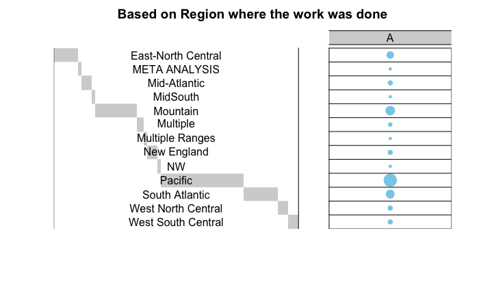

```r
library(gplots)
# 1. convert the data as a table
dt <- as.table(as.matrix(tally(EcologyBias$`Regions where the work was done  (Popo defines)`)))
# 2. Graph
balloonplot(t(dt), main ="Based on Region where the work was done", xlab ="", ylab="",
            label = FALSE, show.margins = FALSE)
```

```r
favstats(~(tally(EcologyBias$`Regions where the work was done  (Popo defines)`)), data = EcologyBias)
```

```
Not respecting matrix dimensions.  Hope that's OK.
```

|  | min | Q1 | median | Q3 | max | mean | sd | n | missing |
| --- | --- | --- | --- | --- | --- | --- | --- | --- | --- |
|  | 1 | 1.25 | 3 | 9.25 | 104 | 12.5 | 27.09172 | 14 | 0 |

```r
favstats(~(tally(EcologyBias$`Phylum`)), data = EcologyBias)
```

```
Not respecting matrix dimensions.  Hope that's OK.
```

|  | min | Q1 | median | Q3 | max | mean | sd | n | missing |
| --- | --- | --- | --- | --- | --- | --- | --- | --- | --- |
|  | 1 | 1.25 | 3 | 17.5 | 71 | 12.5 | 20.09497 | 14 | 0 |

```r
favstats(~(tally(EcologyBias$`Location of first author (region)`)), data = EcologyBias)
```

```
Not respecting matrix dimensions.  Hope that's OK.
```

|  | min | Q1 | median | Q3 | max | mean | sd | n | missing |
| --- | --- | --- | --- | --- | --- | --- | --- | --- | --- |
|  | 2 | 4.25 | 11.5 | 16.75 | 81 | 17.5 | 23.38684 | 10 | 0 |

```r
Ecosystem <- EcologyBias[,16]
Ecosystem
```

| Marine, Terrestrial, Freshwater, Mixed |
| --- |
| Terrestrial |
| Terrestrial |
| Terrestrial |
| Terrestrial |
| Terrestrial |
| Terrestrial |
| Terrestrial |
| Terrestrial |
| Terrestrial |
| Terrestrial |

[output cut: 165 more lines]

```r
class.clean <- na.omit(Ecosystem)
class.clean
```

| Marine, Terrestrial, Freshwater, Mixed |
| --- |
| Terrestrial |
| Terrestrial |
| Terrestrial |
| Terrestrial |
| Terrestrial |
| Terrestrial |
| Terrestrial |
| Terrestrial |
| Terrestrial |
| Terrestrial |

[output cut: 165 more lines]

```r
continent.work <- as.vector(EcologyBias$`Continent where work done`)
remove <- c ("Europe & Oceania", "META ANALYSIS","META ANALYSIS!")
continent.work %in% remove
```

```
  [1] FALSE FALSE FALSE FALSE FALSE FALSE FALSE FALSE FALSE FALSE FALSE FALSE FALSE FALSE
 [15] FALSE FALSE FALSE FALSE FALSE FALSE FALSE FALSE FALSE FALSE FALSE FALSE  TRUE FALSE
 [29] FALSE FALSE FALSE FALSE FALSE FALSE FALSE  TRUE FALSE FALSE FALSE FALSE FALSE FALSE
 [43] FALSE FALSE FALSE FALSE FALSE FALSE FALSE FALSE FALSE FALSE FALSE FALSE FALSE FALSE
 [57] FALSE FALSE FALSE FALSE FALSE FALSE FALSE FALSE FALSE FALSE FALSE FALSE FALSE FALSE
 [71] FALSE FALSE FALSE FALSE FALSE FALSE FALSE FALSE FALSE  TRUE FALSE FALSE FALSE FALSE
 [85] FALSE FALSE FALSE FALSE FALSE FALSE FALSE FALSE FALSE FALSE FALSE FALSE FALSE FALSE
 [99] FALSE FALSE FALSE FALSE FALSE FALSE FALSE FALSE FALSE FALSE  TRUE FALSE FALSE FALSE
[113] FALSE FALSE FALSE FALSE FALSE FALSE FALSE FALSE FALSE FALSE FALSE FALSE FALSE FALSE
[127] FALSE  TRUE FALSE FALSE FALSE FALSE FALSE FALSE FALSE FALSE FALSE FALSE FALSE FALSE
[141] FALSE FALSE FALSE FALSE FALSE FALSE  TRUE FALSE FALSE FALSE FALSE  TRUE FALSE FALSE
[155] FALSE FALSE FALSE FALSE FALSE FALSE FALSE FALSE FALSE FALSE FALSE FALSE FALSE FALSE
[169] FALSE FALSE FALSE FALSE FALSE FALSE FALSE
```

```r
continent.work <- continent.work [! continent.work %in% remove]
continent.work[43] <- "Oceania"
continent.work[61] <- "Oceania"
continent.work <- c(continent.work[1:97], continent.work[99:168])
continent.work
```

```
  [1] "North America" "North America" "North America" "North America" "North America"
  [6] "North America" "South America" "South America" "North America" "North America"
 [11] "North America" "North America" "Europe"        "South America" "Europe"
 [16] "Europe"        "Europe"        "Africa"        "North America" "Asia"
 [21] "North America" "North America" "Asia"          "North America" "Europe"
 [26] "Europe"        "North America" "Europe"        "North America" "North America"
 [31] "North America" "North America" "North America" "North America" "North America"
 [36] "North America" "North America" "South America" "North America" "North America"
 [41] "North America" "Europe"        "Oceania"       "North America" "North America"
 [46] "Europe"        "North America" "North America" "North America" "Asia"
 [51] "North America" "Europe"        "Africa"        "Oceania"       "North America"
 [56] "North America" "North America" "North America" "North America" "Europe"
 [61] "Oceania"       "Asia"          "Europe"        "North America" "North America"
 [66] "Europe"        "North America" "North America" "Europe"        "Asia"
 [71] "North America" "Asia"          "North America" "South America" "Africa"
```

[output cut: 19 more lines]

```r
tally(continent.work)
```

```
X
       Africa          Asia     Australia        Europe North America       Oceania
            5            14             2            34            94             5
South America
           13
```

```r
chisq.test(tally(continent.work))
```

```
    Chi-squared test for given probabilities

data:  tally(continent.work)
X-squared = 269.39, df = 6, p-value < 2.2e-16
```

##State where work was done

```r
State.work <- as.vector(EcologyBias$`State or Municipality where the work was done`)
remove <- c ("Multiple", "META ANALYSIS","Multiple States")
State.work %in% remove
```

```
  [1]  TRUE FALSE FALSE FALSE
  [5] FALSE FALSE FALSE FALSE
  [9] FALSE FALSE FALSE FALSE
 [13] FALSE FALSE FALSE FALSE
 [17] FALSE FALSE FALSE FALSE
 [21]  TRUE FALSE FALSE FALSE
 [25] FALSE FALSE FALSE FALSE
 [29] FALSE FALSE FALSE FALSE
 [33] FALSE FALSE FALSE FALSE
 [37] FALSE FALSE FALSE FALSE
 [41] FALSE FALSE FALSE FALSE
 [45] FALSE FALSE  TRUE FALSE
 [49] FALSE FALSE FALSE FALSE
 [53] FALSE FALSE FALSE FALSE
 [57] FALSE FALSE FALSE FALSE
```

[output cut: 29 more lines]

```r
State.work <- State.work [! State.work %in% remove]

State.work <- State.work[!is.na(State.work)]
State.work
```

```
 [1] "AK"          "AK"
 [3] "WY"          "NC"
 [5] "MT"          "NY"
 [7] "FL"          "WA"
 [9] "KS"          "WI"
[11] "TX"          "OR"
[13] "TX"          "AZ"
[15] "MI"          "CA"
[17] "WA"          "MA"
[19] "CA"          "OR"
[21] "FL"          "CA"
[23] "MD"          "CO"
[25] "CA"          "Puerto Rico"
[27] "CA"          "NM"
[29] "OR/CA"       "CA"
```

[output cut: 17 more lines]

```r
tally(State.work)
```

```
X
         AK          AL
          2           2
         AZ          CA
          3          13
         CO          FL
          2           4
      GA/FL          HI
          1           1
         IN          KS
          1           2
         MA          MD
          1           1
         MI          MO
          4           1
         MT          NC
          1           1
         NH          NJ
          1           2
         NM          NY
          1           1
 NY, MA, CT          OH
          1           1
         OR       OR/CA
          4           1
Puerto Rico          TX
          2           3
         UT          WA
          1           3
         WI          WY
          1           2
```

```r
chisq.test(tally(State.work))
```

```
Chi-squared approximation may be incorrect
```

```
    Chi-squared test for given
    probabilities

data:  tally(State.work)
X-squared = 71, df = 29,
p-value = 2.21e-05
```

Our pvalue is still coming back the same

##State where work was done, DELETED THE MULTIPLE STATE ONES WITHN GIVEN STATES

```r
State.work <- as.vector(EcologyBias$`State or Municipality where the work was done`)
remove <- c ("Multiple", "META ANALYSIS","Multiple States", "GA/FL", "OR/CA", "NY, MA, CT")
State.work %in% remove
```

```
  [1]  TRUE FALSE FALSE FALSE
  [5] FALSE FALSE FALSE FALSE
  [9] FALSE FALSE FALSE FALSE
 [13] FALSE FALSE FALSE FALSE
 [17] FALSE FALSE FALSE FALSE
 [21]  TRUE FALSE FALSE FALSE
 [25] FALSE FALSE FALSE FALSE
 [29] FALSE FALSE FALSE FALSE
 [33] FALSE FALSE FALSE FALSE
 [37] FALSE FALSE FALSE FALSE
 [41] FALSE FALSE FALSE FALSE
 [45] FALSE FALSE  TRUE FALSE
 [49] FALSE FALSE FALSE FALSE
 [53] FALSE FALSE FALSE FALSE
 [57] FALSE FALSE FALSE FALSE
```

[output cut: 29 more lines]

```r
State.work <- State.work [! State.work %in% remove]

State.work <- State.work[!is.na(State.work)]
State.work
```

```
 [1] "AK"          "AK"
 [3] "WY"          "NC"
 [5] "MT"          "NY"
 [7] "FL"          "WA"
 [9] "KS"          "WI"
[11] "TX"          "OR"
[13] "TX"          "AZ"
[15] "MI"          "CA"
[17] "WA"          "MA"
[19] "CA"          "OR"
[21] "FL"          "CA"
[23] "MD"          "CO"
[25] "CA"          "Puerto Rico"
[27] "CA"          "NM"
[29] "CA"          "OR"
```

[output cut: 16 more lines]

```r
tally(State.work)
```

```
X
         AK          AL
          2           2
         AZ          CA
          3          13
         CO          FL
          2           4
         HI          IN
          1           1
         KS          MA
          2           1
         MD          MI
          1           4
         MO          MT
          1           1
         NC          NH
          1           1
         NJ          NM
          2           1
         NY          OH
          1           1
         OR Puerto Rico
          4           2
         TX          UT
          3           1
         WA          WI
          3           1
         WY
          2
```

```r
chisq.test(tally(State.work))
```

```
Chi-squared approximation may be incorrect
```

```
    Chi-squared test for given
    probabilities

data:  tally(State.work)
X-squared = 65.148, df = 26,
p-value = 3.284e-05
```

our pvalue is still coming back the same

```r
SquMil <- Square_Mileage[1:50, ]
SquMil
```

| Continent | Sq. mi (million mi^2) | U.S. States | Total Sq. mi (mi^2) | Land Sq. mi (mi^2) | Water Sq. mi (mi^2) | Regions | Sq. mi (mi^2) |
| --- | --- | --- | --- | --- | --- | --- | --- |
| North America | 9.540 | Alabama | 52423 | 50750 | 1673 | Mid-Atlantic | 191308 |
| South America | 6.888 | Alaska | 656424 | 570374 | 86051 | South Atlantic | 292589 |
| Europe | 3.931 | Arizona | 114006 | 113642 | 364 | East-North Central | 299170 |
| Africa | 11.730 | Arkansas | 53182 | 52075 | 1107 | North West | 5469 |
| Asia | 17.210 | California | 163707 | 155973 | 7734 | Mountain | N/A |
| Australia | 2.970 | Colorado | 104100 | 103730 | 371 | West South Central | 444100 |
| Oceania | 3.292 | Connecticut | 5544 | 4845 | 698 | Pacific | N/A |
| NA | NA | Delaware | 2489 | 1955 | 535 | West North Central | 507900 |
| NA | NA | Florida | 59988 | 53997 | 5991 | New England | 71992 |
| NA | NA | Georgia | 59441 | 57919 | 1522 | Mid South | N/A |

[output cut: 40 more lines]

Fav stats for total Sq.Mil given all 50 states

```r
favstats(~(SquMil$'Total Sq. mi (mi^2)'), data = SquMil)
```

|  | min | Q1 | median | Q3 | max | mean | sd | n | missing |
| --- | --- | --- | --- | --- | --- | --- | --- | --- | --- |
|  | 1545 | 37417.75 | 57097 | 84571.5 | 656424 | 75519.26 | 96310.57 | 50 | 0 |

fav stats for total Sq.Mil given Continent

```r
favstats(~(SquMil$'Sq. mi (million mi^2)'), data = SquMil)
```

|  | min | Q1 | median | Q3 | max | mean | sd | n | missing |
| --- | --- | --- | --- | --- | --- | --- | --- | --- | --- |
|  | 2.97 | 3.6115 | 6.888 | 10.635 | 17.21 | 7.937286 | 5.265304 | 7 | 43 |

```r
chisq.test(SquMil$`Total Sq. mi (mi^2)`)
```

```
    Chi-squared test for given probabilities

data:  SquMil$`Total Sq. mi (mi^2)`
X-squared = 6018473, df = 49, p-value < 2.2e-16
```

# Chisq test ecosystems popo def

```r
eco.po <- as.vector(EcologyBias$`Marine, Terrestrial, Freshwater, Mixed`)
eco.po
```

```
  [1] "Terrestrial" "Terrestrial" "Terrestrial" "Terrestrial" "Terrestrial"
  [6] "Terrestrial" "Terrestrial" "Terrestrial" "Terrestrial" "Terrestrial"
 [11] "Terrestrial" "Terrestrial" "Terrestrial" "Terrestrial" "Marine"
 [16] "Marine"      "Terrestrial" "Terrestrial" "Terrestrial" "Terrestrial"
 [21] "Terrestrial" "Terrestrial" "Terrestrial" "Terrestrial" "Mixed"
 [26] "Terrestrial" "Terrestrial" "Freshwater"  "Freshwater"  "Mixed"
 [31] "Mixed"       "Terrestrial" "Terrestrial" "Terrestrial" "Marine"
 [36] "Terrestrial" "Terrestrial" "Terrestrial" "Terrestrial" "Terrestrial"
 [41] "Terrestrial" "Terrestrial" "Terrestrial" "Terrestrial" "Terrestrial"
 [46] "Terrestrial" "Terrestrial" "Mixed"       "Terrestrial" "Freshwater"
 [51] "Terrestrial" "Terrestrial" "Marine"      "Terrestrial" "Terrestrial"
 [56] "Terrestrial" "Terrestrial" "Terrestrial" "Terrestrial" "Terrestrial"
 [61] "Marine"      "Mixed"       "Marine"      "Terrestrial" "Terrestrial"
 [66] "Terrestrial" "Terrestrial" "Terrestrial" "Terrestrial" "Terrestrial"
 [71] "Terrestrial" "Mixed"       "Terrestrial" "Mixed"       "Mixed"
```

[output cut: 20 more lines]

```r
remove <- c ("Mixed")
eco.po %in% remove
```

```
  [1] FALSE FALSE FALSE FALSE FALSE FALSE FALSE FALSE FALSE FALSE FALSE FALSE FALSE
 [14] FALSE FALSE FALSE FALSE FALSE FALSE FALSE FALSE FALSE FALSE FALSE  TRUE FALSE
 [27] FALSE FALSE FALSE  TRUE  TRUE FALSE FALSE FALSE FALSE FALSE FALSE FALSE FALSE
 [40] FALSE FALSE FALSE FALSE FALSE FALSE FALSE FALSE  TRUE FALSE FALSE FALSE FALSE
 [53] FALSE FALSE FALSE FALSE FALSE FALSE FALSE FALSE FALSE  TRUE FALSE FALSE FALSE
 [66] FALSE FALSE FALSE FALSE FALSE FALSE  TRUE FALSE  TRUE  TRUE FALSE FALSE FALSE
 [79] FALSE FALSE FALSE FALSE FALSE FALSE FALSE FALSE FALSE FALSE FALSE FALSE  TRUE
 [92] FALSE FALSE FALSE FALSE FALSE  TRUE FALSE FALSE FALSE FALSE FALSE FALSE  TRUE
[105] FALSE FALSE FALSE FALSE FALSE FALSE FALSE FALSE FALSE FALSE FALSE FALSE FALSE
[118]  TRUE FALSE FALSE FALSE FALSE FALSE  TRUE FALSE FALSE FALSE FALSE FALSE FALSE
[131] FALSE FALSE FALSE FALSE FALSE FALSE FALSE FALSE FALSE FALSE FALSE FALSE FALSE
[144] FALSE FALSE FALSE FALSE FALSE FALSE FALSE  TRUE  TRUE FALSE FALSE FALSE FALSE
[157] FALSE FALSE FALSE FALSE FALSE  TRUE FALSE FALSE FALSE FALSE FALSE FALSE FALSE
[170] FALSE FALSE FALSE FALSE FALSE FALSE
```

```r
eco.po <- eco.po [! eco.po %in% remove]
eco.po
```

```
  [1] "Terrestrial" "Terrestrial" "Terrestrial" "Terrestrial" "Terrestrial"
  [6] "Terrestrial" "Terrestrial" "Terrestrial" "Terrestrial" "Terrestrial"
 [11] "Terrestrial" "Terrestrial" "Terrestrial" "Terrestrial" "Marine"
 [16] "Marine"      "Terrestrial" "Terrestrial" "Terrestrial" "Terrestrial"
 [21] "Terrestrial" "Terrestrial" "Terrestrial" "Terrestrial" "Terrestrial"
 [26] "Terrestrial" "Freshwater"  "Freshwater"  "Terrestrial" "Terrestrial"
 [31] "Terrestrial" "Marine"      "Terrestrial" "Terrestrial" "Terrestrial"
 [36] "Terrestrial" "Terrestrial" "Terrestrial" "Terrestrial" "Terrestrial"
 [41] "Terrestrial" "Terrestrial" "Terrestrial" "Terrestrial" "Terrestrial"
 [46] "Freshwater"  "Terrestrial" "Terrestrial" "Marine"      "Terrestrial"
 [51] "Terrestrial" "Terrestrial" "Terrestrial" "Terrestrial" "Terrestrial"
 [56] "Terrestrial" "Marine"      "Marine"      "Terrestrial" "Terrestrial"
 [61] "Terrestrial" "Terrestrial" "Terrestrial" "Terrestrial" "Terrestrial"
 [66] "Terrestrial" "Terrestrial" "Terrestrial" "Terrestrial" "Marine"
 [71] "Terrestrial" "Terrestrial" "Terrestrial" "Terrestrial" "Terrestrial"
```

[output cut: 17 more lines]

```r
tally(eco.po)
```

```
X
 Freshwater      Marine Terrestrial
         12          20         127
```

```r
chisq.test(tally(eco.po))
```

```
    Chi-squared test for given probabilities

data:  tally(eco.po)
X-squared = 155.58, df = 2, p-value < 2.2e-16
```

# Chisq ecosystem ped def

```r
eco.ped <- as.vector(EcologyBias$`Ecosystem (Ped defines)`)

remove <- c ("Multiple", "META-ANALYSIS")
eco.ped %in% remove
```

```
  [1] FALSE FALSE FALSE FALSE FALSE FALSE FALSE FALSE FALSE  TRUE FALSE FALSE FALSE
 [14] FALSE FALSE FALSE FALSE FALSE FALSE FALSE FALSE FALSE FALSE FALSE FALSE FALSE
 [27]  TRUE FALSE FALSE FALSE FALSE FALSE FALSE FALSE FALSE  TRUE FALSE FALSE FALSE
 [40] FALSE FALSE FALSE FALSE FALSE FALSE FALSE FALSE FALSE FALSE FALSE FALSE FALSE
 [53] FALSE FALSE FALSE FALSE FALSE FALSE FALSE FALSE FALSE FALSE FALSE FALSE FALSE
 [66] FALSE FALSE FALSE FALSE FALSE FALSE FALSE FALSE FALSE FALSE FALSE FALSE FALSE
 [79] FALSE FALSE FALSE FALSE FALSE FALSE FALSE FALSE FALSE FALSE FALSE FALSE FALSE
 [92] FALSE FALSE FALSE FALSE FALSE FALSE FALSE FALSE FALSE FALSE FALSE FALSE FALSE
[105] FALSE FALSE FALSE FALSE FALSE FALSE FALSE FALSE FALSE FALSE FALSE FALSE FALSE
[118] FALSE FALSE FALSE FALSE FALSE FALSE FALSE FALSE FALSE FALSE FALSE FALSE FALSE
[131] FALSE FALSE FALSE FALSE FALSE FALSE FALSE FALSE FALSE FALSE FALSE FALSE FALSE
[144] FALSE FALSE FALSE  TRUE FALSE FALSE FALSE FALSE  TRUE FALSE FALSE FALSE FALSE
[157] FALSE FALSE FALSE FALSE FALSE FALSE FALSE FALSE FALSE FALSE FALSE FALSE FALSE
[170] FALSE FALSE FALSE FALSE FALSE FALSE
```

```r
eco.ped <- eco.ped [! eco.ped %in% remove]

eco.ped <- c(eco.ped[1:50], eco.ped[52:169])
eco.ped
```

```
  [1] "Temperate Deciduous Forests"           "Polar & Alpine Tundra"
  [3] "Polar & Alpine Tundra"                 "Shrublands"
  [5] "Coniferous and Hardwood"               "Temperate Deciduous Forests"
  [7] "Tropical Forests"                      "Deciduous and Evergreen"
  [9] "Natural Grasslands"                    "Temperate Broad Leaved Evergreen"
 [11] "Natural Grasslands"                    "Natural Grasslands"
 [13] "Tropical Forests"                      "Ecosystems of the Deep Ocean"
 [15] "Managed Aquatic Ecosystems"            "Natural Grasslands"
 [17] "Tropical Savannas"                     "Tropical Forests"
 [19] "Natural Grasslands"                    "Shrublands"
 [21] "Natural Grasslands"                    "Tropical Forests"
 [23] "Coniferous Forests"                    "Temperate Broad Leaved Evergreen"
 [25] "Managed Terrestrial Ecosystems"        "River and Stream Ecosystem"
 [27] "Lakes and Reservoirs Ecosystems"       "Lakes and Reservoirs Ecosystems"
 [29] "Coniferous Forests"                    "Temperate Deserts and Semi Deserts"
```

[output cut: 69 more lines]

```r
tally(eco.ped)
```

```
X
                   Coastal Ecosystems               Coniferous and Hardwood
                                   10                                     1
                   Coniferous Forests                           Coral Reefs
                                    6                                     4
              Deciduous and Evergreen Ecosystems of the Continental Shelves
                                    1                                     3
         Ecosystems of the Deep Ocean           Estuaries and Enclosed Seas
                                    1                                     2
            Inland Aquatic Ecosystems    Intertidal and Littoral Ecosystems
                                    3                                     6
      Lakes and Reservoirs Ecosystems            Managed Aquatic Ecosystems
                                    8                                     2
       Managed Terrestrial Ecosystems                    Natural Grasslands
                                   16                                    20
                Polar & Alpine Tundra            River and Stream Ecosystem
                                    5                                     8
                           Shrublands      Temperate Broad Leaved Evergreen
                                    6                                     4
          Temperate Deciduous Forests    Temperate Deserts and Semi Deserts
                                   23                                     4
                     Tropical Forests                     Tropical Savannas
                                   27                                     4
                      Wetland Forests
                                    4
```

```r
chisq.test(tally(eco.ped))
```

```
    Chi-squared test for given probabilities

data:  tally(eco.ped)
X-squared = 158.38, df = 22, p-value < 2.2e-16
```

Continent where work was done cleaned

```r
Continent.work <- as.vector(EcologyBias$`Continent where work done`)
remove <- c ("Europe & Oceania", "META ANALYSIS","META ANALYSIS!")
Continent.work %in% remove
```

```
  [1] FALSE FALSE FALSE FALSE FALSE FALSE FALSE FALSE FALSE FALSE FALSE FALSE FALSE
 [14] FALSE FALSE FALSE FALSE FALSE FALSE FALSE FALSE FALSE FALSE FALSE FALSE FALSE
 [27]  TRUE FALSE FALSE FALSE FALSE FALSE FALSE FALSE FALSE  TRUE FALSE FALSE FALSE
 [40] FALSE FALSE FALSE FALSE FALSE FALSE FALSE FALSE FALSE FALSE FALSE FALSE FALSE
 [53] FALSE FALSE FALSE FALSE FALSE FALSE FALSE FALSE FALSE FALSE FALSE FALSE FALSE
 [66] FALSE FALSE FALSE FALSE FALSE FALSE FALSE FALSE FALSE FALSE FALSE FALSE FALSE
 [79] FALSE  TRUE FALSE FALSE FALSE FALSE FALSE FALSE FALSE FALSE FALSE FALSE FALSE
 [92] FALSE FALSE FALSE FALSE FALSE FALSE FALSE FALSE FALSE FALSE FALSE FALSE FALSE
[105] FALSE FALSE FALSE FALSE  TRUE FALSE FALSE FALSE FALSE FALSE FALSE FALSE FALSE
[118] FALSE FALSE FALSE FALSE FALSE FALSE FALSE FALSE FALSE FALSE  TRUE FALSE FALSE
[131] FALSE FALSE FALSE FALSE FALSE FALSE FALSE FALSE FALSE FALSE FALSE FALSE FALSE
[144] FALSE FALSE FALSE  TRUE FALSE FALSE FALSE FALSE  TRUE FALSE FALSE FALSE FALSE
[157] FALSE FALSE FALSE FALSE FALSE FALSE FALSE FALSE FALSE FALSE FALSE FALSE FALSE
[170] FALSE FALSE FALSE FALSE FALSE FALSE
```

```r
Continent.work <- Continent.work [! Continent.work %in% remove]
Continent.work[43] <- "Oceania"
Continent.work[61] <- "Oceania"
Continent.work <- c(Continent.work[1:97], Continent.work[99:168])
Continent.work
```

```
  [1] "North America" "North America" "North America" "North America" "North America"
  [6] "North America" "South America" "South America" "North America" "North America"
 [11] "North America" "North America" "Europe"        "South America" "Europe"
 [16] "Europe"        "Europe"        "Africa"        "North America" "Asia"
 [21] "North America" "North America" "Asia"          "North America" "Europe"
 [26] "Europe"        "North America" "Europe"        "North America" "North America"
 [31] "North America" "North America" "North America" "North America" "North America"
 [36] "North America" "North America" "South America" "North America" "North America"
 [41] "North America" "Europe"        "Oceania"       "North America" "North America"
 [46] "Europe"        "North America" "North America" "North America" "Asia"
 [51] "North America" "Europe"        "Africa"        "Oceania"       "North America"
 [56] "North America" "North America" "North America" "North America" "Europe"
 [61] "Oceania"       "Asia"          "Europe"        "North America" "North America"
 [66] "Europe"        "North America" "North America" "Europe"        "Asia"
 [71] "North America" "Asia"          "North America" "South America" "Africa"
```

[output cut: 19 more lines]

```r
tally(Continent.work)
```

```
X
       Africa          Asia     Australia        Europe North America       Oceania
            5            14             2            34            94             5
South America
           13
```

```r
chisq.test(tally(Continent.work))
```

```
    Chi-squared test for given probabilities

data:  tally(Continent.work)
X-squared = 269.39, df = 6, p-value < 2.2e-16
```

# continent.work

```r
xchisq.test(tally(Continent.work))
```

```
    Chi-squared test for given probabilities

data:  x
X-squared = 269.39, df = 6, p-value < 2.2e-16

    5       14        2       34       94        5       13
(23.86)  (23.86)  (23.86)  (23.86)  (23.86)  (23.86)  (23.86)
[ 14.91] [  4.07] [ 20.02] [  4.31] [206.23] [ 14.91] [  4.94]
<-3.86>  <-2.02>  <-4.47>  < 2.08>  <14.36>  <-3.86>  <-2.22>

key:
    observed
    (expected)
    [contribution to X-squared]
    <Pearson residual>
```

# eco.po

```r
x <- tally(eco.po)
x <- as.matrix(x)
x
```

```
            [,1]
Freshwater    12
Marine        20
Terrestrial  127
```

```r
xchisq.test(x)
```

```
    Chi-squared test for given probabilities

data:  x
X-squared = 155.58, df = 2, p-value < 2.2e-16

   12       20      127
(53.00)  (53.00)  (53.00)
[ 31.72] [ 20.55] [103.32]
<-5.63>  <-4.53>  <10.16>

key:
    observed
    (expected)
    [contribution to X-squared]
    <Pearson residual>
```

This data shows us the expected number each ecosystem is suppose to have given that all ecosystems had a fair chance of being “picked”. This information explains why a pvalue soooooo small happened because comparing to the expected number and the actual number there is no close similarities. Which leads our findings to having bias in ecosystems. # eco.ped

```r
xchisq.test(tally(eco.ped))
```

```
    Chi-squared test for given probabilities

data:  x
X-squared = 158.38, df = 22, p-value < 2.2e-16

   10        1        6        4        1        3        1        2        3        6        8        2       16       20        5        8        6        4       23        4       27        4        4
 (7.30)   (7.30)   (7.30)   (7.30)   (7.30)   (7.30)   (7.30)   (7.30)   (7.30)   (7.30)   (7.30)   (7.30)   (7.30)   (7.30)   (7.30)   (7.30)   (7.30)   (7.30)   (7.30)   (7.30)   (7.30)   (7.30)   (7.30)
[ 0.995] [ 5.441] [ 0.233] [ 1.495] [ 5.441] [ 2.536] [ 5.441] [ 3.852] [ 2.536] [ 0.233] [ 0.066] [ 3.852] [10.352] [22.066] [ 0.727] [ 0.066] [ 0.233] [ 1.495] [33.727] [ 1.495] [53.108] [ 1.495] [ 1.495]
< 1.00>  <-2.33>  <-0.48>  <-1.22>  <-2.33>  <-1.59>  <-2.33>  <-1.96>  <-1.59>  <-0.48>  < 0.26>  <-1.96>  < 3.22>  < 4.70>  <-0.85>  < 0.26>  <-0.48>  <-1.22>  < 5.81>  <-1.22>  < 7.29>  <-1.22>  <-1.22>

key:
    observed
    (expected)
    [contribution to X-squared]
    <Pearson residual>
```

# Pie Chart of Ecosystem of Observed

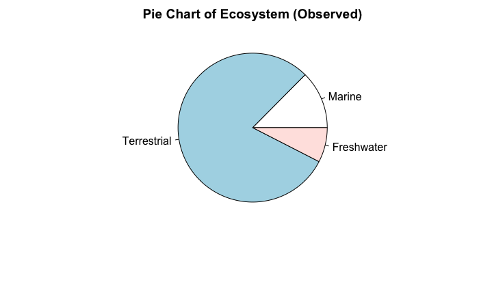

```r
slices <- c(20,127,12)
lbls <- c("Marine", "Terrestrial", "Freshwater")
pie(slices, labels = lbls, main="Pie Chart of Ecosystem (Observed)")
```

# Pie Chart of Ecosystem of Expected

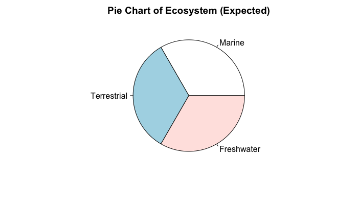

```r
slicesExp <- c(53,53,53)
lbls <- c("Marine", "Terrestrial", "Freshwater")
pie(slicesExp, labels = lbls, main = "Pie Chart of Ecosystem (Expected)" )
```

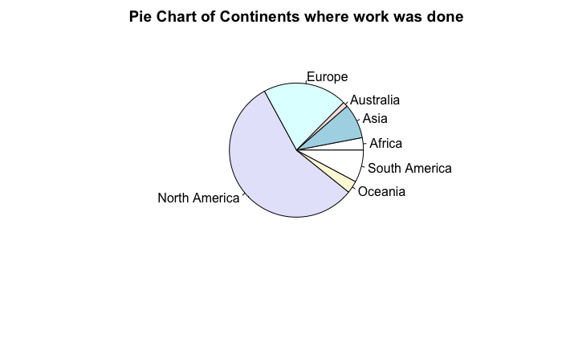

```r
slices <- c(5,14,2,34,94,5,13)
lbls <- c("Africa", "Asia", "Australia", "Europe", " North America", "Oceania", "South America")
pie(slices, labels = lbls, main="Pie Chart of Continents where work was done")
```

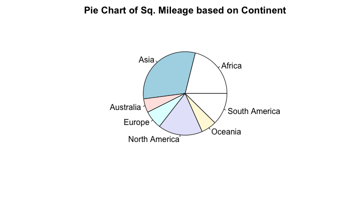

```r
slices <- c(11.73,17.21,2.97,3.931,9.54,3.292,6.888)
lbls <- c("Africa", "Asia", "Australia", "Europe", " North America", "Oceania", "South America")
pie(slices, labels = lbls, main="Pie Chart of Sq. Mileage based on Continent")
```

# Chisq test Continent

```r
continent.work <- as.vector(EcologyBias$`Continent where work done`)
remove <- c ("Europe & Oceania", "META ANALYSIS","META ANALYSIS!")
continent.work %in% remove
```

```
  [1] FALSE FALSE FALSE FALSE FALSE FALSE FALSE FALSE FALSE FALSE FALSE FALSE FALSE FALSE FALSE FALSE
 [17] FALSE FALSE FALSE FALSE FALSE FALSE FALSE FALSE FALSE FALSE  TRUE FALSE FALSE FALSE FALSE FALSE
 [33] FALSE FALSE FALSE  TRUE FALSE FALSE FALSE FALSE FALSE FALSE FALSE FALSE FALSE FALSE FALSE FALSE
 [49] FALSE FALSE FALSE FALSE FALSE FALSE FALSE FALSE FALSE FALSE FALSE FALSE FALSE FALSE FALSE FALSE
 [65] FALSE FALSE FALSE FALSE FALSE FALSE FALSE FALSE FALSE FALSE FALSE FALSE FALSE FALSE FALSE  TRUE
 [81] FALSE FALSE FALSE FALSE FALSE FALSE FALSE FALSE FALSE FALSE FALSE FALSE FALSE FALSE FALSE FALSE
 [97] FALSE FALSE FALSE FALSE FALSE FALSE FALSE FALSE FALSE FALSE FALSE FALSE  TRUE FALSE FALSE FALSE
[113] FALSE FALSE FALSE FALSE FALSE FALSE FALSE FALSE FALSE FALSE FALSE FALSE FALSE FALSE FALSE  TRUE
[129] FALSE FALSE FALSE FALSE FALSE FALSE FALSE FALSE FALSE FALSE FALSE FALSE FALSE FALSE FALSE FALSE
[145] FALSE FALSE  TRUE FALSE FALSE FALSE FALSE  TRUE FALSE FALSE FALSE FALSE FALSE FALSE FALSE FALSE
[161] FALSE FALSE FALSE FALSE FALSE FALSE FALSE FALSE FALSE FALSE FALSE FALSE FALSE FALSE FALSE
```

```r
continent.work <- continent.work [! continent.work %in% remove]
continent.work[43] <- "Oceania"
continent.work[61] <- "Oceania"
continent.work <- c(continent.work[1:97], continent.work[99:168])
continent.work
```

```
  [1] "North America" "North America" "North America" "North America" "North America" "North America"
  [7] "South America" "South America" "North America" "North America" "North America" "North America"
 [13] "Europe"        "South America" "Europe"        "Europe"        "Europe"        "Africa"
 [19] "North America" "Asia"          "North America" "North America" "Asia"          "North America"
 [25] "Europe"        "Europe"        "North America" "Europe"        "North America" "North America"
 [31] "North America" "North America" "North America" "North America" "North America" "North America"
 [37] "North America" "South America" "North America" "North America" "North America" "Europe"
 [43] "Oceania"       "North America" "North America" "Europe"        "North America" "North America"
 [49] "North America" "Asia"          "North America" "Europe"        "Africa"        "Oceania"
 [55] "North America" "North America" "North America" "North America" "North America" "Europe"
 [61] "Oceania"       "Asia"          "Europe"        "North America" "North America" "Europe"
 [67] "North America" "North America" "Europe"        "Asia"          "North America" "Asia"
 [73] "North America" "South America" "Africa"        "North America" "North America" "South America"
 [79] "North America" "North America" "South America" "South America" "Europe"        "Australia"
 [85] "North America" "South America" "North America" "North America" "North America" "North America"
 [91] "North America" "North America" "North America" "South America" "North America" "North America"
 [97] "North America" "North America" "North America" "North America" "South America" "Asia"
[103] "North America" "North America" "North America" "North America" "North America" "North America"
[109] "Europe"        "Europe"        "Europe"        "North America" "Asia"          "North America"
[115] "Africa"        "North America" "North America" "South America" "North America" "North America"
[121] "Europe"        "North America" "Europe"        "Europe"        "North America" "North America"
[127] "North America" "North America" "South America" "Asia"          "North America" "Europe"
[133] "Asia"          "North America" "North America" "Asia"          "Australia"     "Asia"
[139] "Europe"        "North America" "Europe"        "Europe"        "North America" "Asia"
[145] "Europe"        "Europe"        "Europe"        "North America" "North America" "Oceania"
[151] "North America" "Europe"        "North America" "Asia"          "North America" "Africa"
[157] "Europe"        "Oceania"       "Europe"        "North America" "Europe"        "Europe"
[163] "North America" "North America" "North America" "North America" "Europe"
```

```r
tally(continent.work)
```

```
X
       Africa          Asia     Australia        Europe North America       Oceania South America
            5            14             2            34            94             5            13
```

```r
chisq.test(tally(continent.work))
```

```
    Chi-squared test for given probabilities

data:  tally(continent.work)
X-squared = 269.39, df = 6, p-value < 2.2e-16
```

# Continent with Sqr mileage

```r
sm.earth <- 197 # sqr miles of earths surface

sm.continent <- c(SqrMileage$`Sq. mi (million mi^2)`)

sm.continent <- as.numeric(sm.continent[2:8])

prop.cont <- sm.continent/sum(sm.continent)
prop.cont
```

```
[1] 0.21111931 0.30974964 0.05345476 0.07075107 0.17170317 0.05925019
[7] 0.12397185
```

```r
chisq.test(tally(continent.work), p=prop.cont)
```

```
    Chi-squared test for given probabilities

data:  tally(continent.work)
X-squared = 254.62, df = 6, p-value < 2.2e-16
```

```r
xchisq.test(tally(continent.work),p=prop.cont )
```

```
    Chi-squared test for given probabilities

data:  x
X-squared = 254.62, df = 6, p-value < 2.2e-16

    5       14        2       34       94        5       13
(35.26)  (51.73)  ( 8.93)  (11.82)  (28.67)  ( 9.89)  (20.70)
[ 25.97] [ 27.52] [  5.38] [ 41.65] [148.82] [  2.42] [  2.87]
<-5.10>  <-5.25>  <-2.32>  < 6.45>  <12.20>  <-1.56>  <-1.69>

key:
    observed
    (expected)
    [contribution to X-squared]
    <Pearson residual>
```

# Chart for Continent with Sqr Mileage

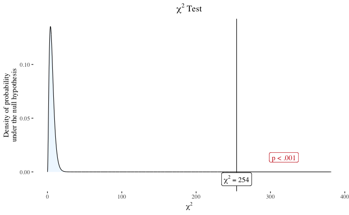

```r
library(nhstplot)
plotchisqtest(254.462, 6)
```

# Chart using the Expected values

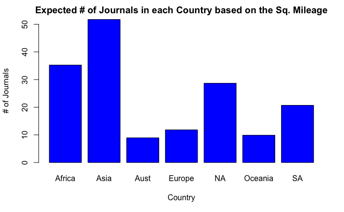

```r
E <- c(35.26, 51.73, 8.93, 11.82, 28.67 ,9.89 ,20.70)
CS <- c("Africa", "Asia", "Aust", "Europe", "NA", "Oceania", "SA")
barplot(E, names.arg = CS, xlab ="Country", ylab = " # of Journals", col = "blue", main = "Expected # of Journals in each Country based on the Sq. Mileage", border = "black")
```

# Chart using the Observed values

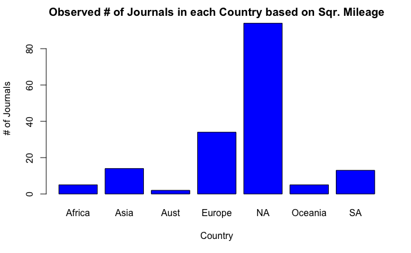

```r
O <- c(5,14,2,34,94,5,13)
C <- c("Africa", "Asia", "Aust", "Europe", "NA", "Oceania", "SA")
barplot(O, names.arg = C, xlab ="Country", ylab = " # of Journals", col = "blue", main = "Observed # of Journals in each Country based on Sqr. Mileage", border = "black")
```

# Chisq test country

```r
country.work <- as.vector(EcologyBias$`Country where the work is done`)
remove <- c ("Brazil/Costa Rica/Puerto Rico", "Germany & New Zealand","Lesser Antilles/Guadelupe", "META ANALYSIS", "Multiple???", "US and Mexico", "Trinidad and Tobago")
country.work %in% remove
country.work <- country.work [! country.work %in% remove]
country.work[1:5] <- "USA"
country.work[8:11] <- "USA"
country.work <- c(country.work[1:25], country.work[27:34], country.work[36:77], country.work[79:95], country.work[97:121], country.work[123:144], country.work[146:168])
country.work
tally(country.work)
chisq.test(tally(country.work))
```

[output not shown]

# Chisq test region

```r
region.work <- as.vector(EcologyBias$`Regions where the work was done  (Popo defines)`)
region.work
```

```
  [1] "Multiple"           "NW"                 "West South Central" "Mountain"
  [5] "Mountain"           "South Atlantic"     NA                   NA
  [9] "Mountain"           "Mid-Atlantic"       "South Atlantic"     "Pacific"
 [13] NA                   NA                   NA                   NA
 [17] NA                   NA                   NA                   NA
 [21] "Multiple"           "West North Central" NA                   "East-North Central"
 [25] NA                   NA                   NA                   "MidSouth"
 [29] NA                   "Pacific"            "West South Central" "Mountain"
 [33] "East-North Central" "Pacific"            "Pacific"            NA
 [37] "New England"        "Pacific"            NA                   NA
 [41] "South Atlantic"     NA                   "Pacific"            NA
 [45] NA                   "Multiple Ranges"    "Mountain"           NA
 [49] NA                   NA                   NA                   NA
 [53] "South Atlantic"     NA                   NA                   NA
 [57] NA                   NA                   NA                   "Pacific"
```

[output cut: 29 more lines]

```r
remove <- c ("Multiple", "META ANALYSIS", "Multiple Ranges", "MidSouth")
region.work %in% remove
```

```
  [1]  TRUE FALSE FALSE FALSE FALSE FALSE FALSE FALSE FALSE FALSE FALSE FALSE FALSE FALSE FALSE FALSE FALSE
 [18] FALSE FALSE FALSE  TRUE FALSE FALSE FALSE FALSE FALSE FALSE  TRUE FALSE FALSE FALSE FALSE FALSE FALSE
 [35] FALSE FALSE FALSE FALSE FALSE FALSE FALSE FALSE FALSE FALSE FALSE  TRUE FALSE FALSE FALSE FALSE FALSE
 [52] FALSE FALSE FALSE FALSE FALSE FALSE FALSE FALSE FALSE FALSE FALSE FALSE FALSE FALSE FALSE FALSE FALSE
 [69] FALSE FALSE FALSE FALSE FALSE FALSE FALSE FALSE FALSE FALSE FALSE FALSE FALSE FALSE FALSE FALSE FALSE
 [86] FALSE FALSE FALSE FALSE FALSE FALSE FALSE FALSE FALSE FALSE FALSE FALSE FALSE FALSE FALSE FALSE FALSE
[103] FALSE FALSE FALSE FALSE FALSE FALSE FALSE FALSE FALSE FALSE FALSE FALSE FALSE FALSE FALSE FALSE FALSE
[120] FALSE FALSE FALSE FALSE FALSE FALSE FALSE FALSE FALSE FALSE FALSE FALSE FALSE FALSE FALSE FALSE FALSE
[137] FALSE FALSE FALSE FALSE FALSE FALSE FALSE FALSE FALSE FALSE  TRUE FALSE FALSE FALSE FALSE FALSE FALSE
[154] FALSE FALSE FALSE FALSE FALSE FALSE FALSE FALSE FALSE FALSE FALSE FALSE FALSE FALSE FALSE FALSE FALSE
[171] FALSE FALSE FALSE FALSE FALSE
```

```r
region.work <- region.work [! region.work %in% remove]
region.work
```

```
  [1] "NW"                 "West South Central" "Mountain"           "Mountain"
  [5] "South Atlantic"     NA                   NA                   "Mountain"
  [9] "Mid-Atlantic"       "South Atlantic"     "Pacific"            NA
 [13] NA                   NA                   NA                   NA
 [17] NA                   NA                   NA                   "West North Central"
 [21] NA                   "East-North Central" NA                   NA
 [25] NA                   NA                   "Pacific"            "West South Central"
 [29] "Mountain"           "East-North Central" "Pacific"            "Pacific"
 [33] NA                   "New England"        "Pacific"            NA
 [37] NA                   "South Atlantic"     NA                   "Pacific"
 [41] NA                   NA                   "Mountain"           NA
 [45] NA                   NA                   NA                   NA
 [49] "South Atlantic"     NA                   NA                   NA
 [53] NA                   NA                   NA                   "Pacific"
 [57] "South Atlantic"     NA                   NA                   NA
```

[output cut: 28 more lines]

```r
region.work <- region.work[!is.na(region.work)]
region.work
```

```
 [1] "NW"                 "West South Central" "Mountain"           "Mountain"
 [5] "South Atlantic"     "Mountain"           "Mid-Atlantic"       "South Atlantic"
 [9] "Pacific"            "West North Central" "East-North Central" "Pacific"
[13] "West South Central" "Mountain"           "East-North Central" "Pacific"
[17] "Pacific"            "New England"        "Pacific"            "South Atlantic"
[21] "Pacific"            "Mountain"           "South Atlantic"     "Pacific"
[25] "South Atlantic"     "Mountain"           "Pacific"            "South Atlantic"
[29] "Pacific"            "Mountain"           "Pacific"            "Pacific"
[33] "Pacific"            "Pacific"            "South Atlantic"     "Mid-Atlantic"
[37] "East-North Central" "Pacific"            "South Atlantic"     "Pacific"
[41] "West North Central" "New England"        "Pacific"            "South Atlantic"
[45] "East-North Central" "Pacific"            "Pacific"            "East-North Central"
[49] "Pacific"            "New England"        "Mountain"           "East-North Central"
[53] "West South Central" "Mountain"           "East-North Central" "Mid-Atlantic"
[57] "Mountain"           "Pacific"            "Mountain"           "Pacific"
[61] "Mountain"           "West North Central" "South Atlantic"     "Pacific"
[65] "Pacific"            "Pacific"
```

```r
tally(region.work)
```

```
X
East-North Central       Mid-Atlantic           Mountain        New England                 NW
                 7                  3                 12                  3                  1
           Pacific     South Atlantic West North Central West South Central
                24                 10                  3                  3
```

```r
chisq.test(tally(region.work))
```

```
    Chi-squared test for given probabilities

data:  tally(region.work)
X-squared = 57.545, df = 8, p-value = 1.409e-09
```

# xChisq test Region

```r
tally(region.work)
```

[output not shown]

```r
xchisq.test(tally(region.work))
```

[output not shown]